# dde

Rich FitzJohn

2024-09-23

The `dde` package implements solvers for ordinary differential equations (ODEs) and *delay* differential equations (DDEs). DDEs differ from ODEs in that the right hand side depends not only on time and the current state of the system but also on the previous state of the system.

This seemingly innocuous dependency can create problems, especially where the delay changes size overtime. In particular, problems where delays are on the order of the step size (vanishing delays) are difficult to solve.

This package is aimed at solving non-stiff ODEs and DDEs with simple delays.

The `deSolve` package already allows for solving delay differential equations, though the interface and approach differs; see below for similarities and differences.

## Ordinary differential equation models

With ODE models you will almost always be better off using `deSolve`. The `deTestSet` package also implements Fortran version of the Dormand Prince algorithms here (as `deTestSet::dopri5` and `deTestSet::dopri853`). If you use `deSolve` then you’ll have the ability to switch between a huge number of different solvers.

The reasons to consider using `dde` over `deSolve`/`deTestSet` would be if you

- are needing to use a DDE equation elsewhere in your package/program
- want to generate dense output for a system for later interpolation

Other than that, I would recommend using `deSolve` (which is what I do).

For completeness, I will show how below

### Models implemented in R

Models implemented in R look very similar to `deSolve`. Here is the Lorenz attractor implemented for `dde`:

```r
lorenz_dde <- function(t, y, p) {
  sigma <- p$sigma
  R     <- p$R
  b     <- p$b
  y1 <- y[[1L]]
  y2 <- y[[2L]]
  y3 <- y[[3L]]
  c(sigma * (y2 - y1),
    R * y1 - y2 - y1 * y3,
    -b * y3 + y1 * y2)
}
```

The `p` argument is the parameters and can be any R object. Here I’ll use a `list` to hold the standard Lorenz attractor parameters:

```r
p <- list(sigma = 10.0,
          R     = 28.0,
          b     =  8.0 / 3.0)

tt <- seq(0, 100, length.out = 50001)
y0 <- c(1, 1, 1)
yy <- dde::dopri(y0, tt, lorenz_dde, p)
```

Here is the iconic attractor

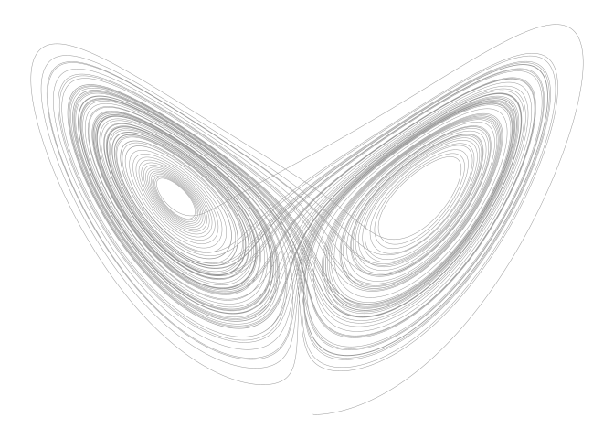

```r
par(mar=rep(.5, 4))
plot(yy[, c(2, 4)], type = "l", lwd = 0.5, col = "#00000066",
     axes = FALSE, xlab = "", ylab = "")
```

The approach above is almost identical to implementing this model using `deSolve`:

```r
lorenz_ds <- function(t, y, p) {
  sigma <- 10.0
  R     <- 28.0
  b     <-  8.0 / 3.0
  y1 <- y[[1L]]
  y2 <- y[[2L]]
  y3 <- y[[3L]]
  list(c(sigma * (y2 - y1),
         R * y1 - y2 - y1 * y3,
         -b * y3 + y1 * y2))
}
yy_ds <- deSolve::ode(y0, tt, lorenz_ds, p)
```

### Dense output and interpolation

One of the nice things about the `dopri` solvers is that they do not need to stop the integration at the times that you request output at:

```r
yy <- dde::dopri(y0, tt, lorenz_dde, p, return_statistics = TRUE)
attr(yy, "statistics")
```

```
##   n_eval   n_step n_accept n_reject
##    26990     4498     4308      190
```

Above, the number of function evaluations (~6 per step), steps, and rejected steps is indicated (a rejected step occurs where the solver has to reduce step size multiple times to achieve the required accuracy). The number of steps here is about 1/10 the number of returned samples. This works because the solver here returns “**dense output**” which allows it to interpolate the solution between points that it has not visited. This is supported by many of the solvers in `deSolve`, too.

In contrast with `deSolve`, the dense output here can be collected and worked with later, though doing this requires a bit of faff.

Specify the history length; this needs to be an *overestimate* because once the end of the history buffer is reached it will be silently overwritten to return the *last* steps in history. (This is the behaviour required to support delay models without running out of memory).

```r
yy2 <- dde::dopri(y0, range(tt), lorenz_dde, p, return_minimal = TRUE,
                  n_history = 5000, return_history = TRUE)
```

With these arguments `yy2` is a 3 x 1 matrix, but it comes with a massive “history” matrix":

```r
dim(yy2)
```

```
## [1] 3 1
```

```r
h <- attr(yy2, "history")
dim(h)
```

```
## [1]   17 4308
```

The contents of this matrix are designed to be opaque (i.e., I may change how things are represented at a future time). However, the solution can be interpolated to any number of points using this matrix:

```r
yy2 <- dde::dopri_interpolate(h, tt)
all.equal(yy2, yy[, -1], check.attributes = FALSE)
```

```
## [1] TRUE
```

## Delay differential equation models

Implementing a delay differential equation model (vs an ODE model) means that you refer to the model state at a previous point in time. To do that, you use the the `ylag` function, of which `dde` provides interfaces in both R and C.

### A model in R

This is a simple SEIR (Susceptible - Exposed - Infected - Resistant) model from epidemiology. Once exposed to the disease, an individual exists in an “Exposed” state for exactly 14 days before becoming “Infected” (you could model this with a series of compartments and get a distribution of exposed times).

```r
seir <- function(t, y, p) {
  b <- 0.1
  N <- 1e7
  beta <- 10.0
  sigma <- 1.0 / 3.0
  delta <- 1.0 / 21.0
  t_latent <- 14.0
  Births <- N * b
  surv <- exp(-b * t_latent)

  S <- y[[1L]]
  E <- y[[2L]]
  I <- y[[3L]]
  R <- y[[4L]]

  tau <- t - t_latent
  y_lag <- dde::ylag(tau, c(1L, 3L)) # Here is ylag!
  S_lag <- y_lag[[1L]]
  I_lag <- y_lag[[2L]]

  new_inf <- beta * S * I / N
  lag_inf <- beta * S_lag * I_lag * surv / N

  c(Births  - b * S - new_inf + delta * R,
    new_inf - lag_inf - b * E,
    lag_inf - (b + sigma) * I,
    sigma * I - b * R - delta * R)
}
```

The model needs to know how many susceptible individuals there were 14 days ago, and how many infected there were 14 days ago. To get this from the model, we use

```r
y_lag <- dde::ylag(tau, c(1L, 3L))
```

to get the values of the first and third variables (S and I) at time `tau`. Alternatively you can get all values with

```r
y_lag <- dde::ylag(tau)
```

or get them individually

```r
S_lag <- dde::ylag(tau, 1L)
I_lag <- dde::ylag(tau, 3L)
```

The `ylag` function can only be called from within an integration; it will throw an error if you try to call it otherwise.

What happens when we start though? If time starts at 0, then the first `tau` is -14 and we have no history then. `dde` keeps track of the initial state of the system and if a time before this is requested it returns the initial state of a variable. This is going to be reasonable for many applications but will lead to discontinuities in the *derivative* of your solution (and the second derivative and so on). This can make the problem hard to solve, and it may be preferable to provide your own information (see the deSolve implementation below for one possible way of implementing this).

To integrate the problem, use the `dde::dopri` function (which by default will use the 5th order method, which is probably the best bet for most problems). You need to provide arguments:

- `n_history`: number of history elements to retain. If this is too low then the integration will stop with an error and you can increase it
- `return_history`: set this to `FALSE` if you won’t want the history matrix returned; returning it costs a little time and if you don’t want to inspect it it’s better to leave it off

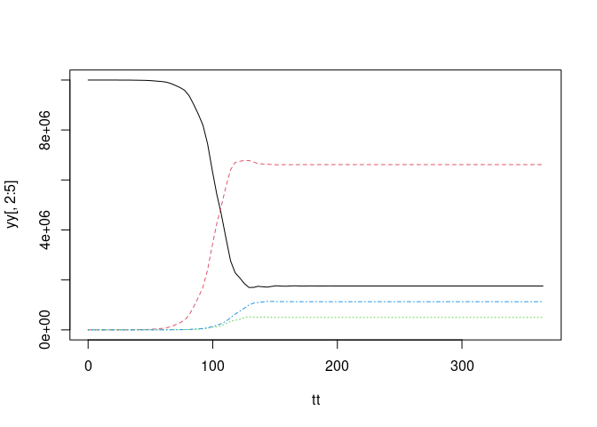

```r
y0 <-  y0 <- c(1e7 - 1, 0, 1, 0)
tt <- seq(0, 365, length.out = 100)
yy <- dde::dopri(y0, tt, seir, NULL, n_history = 1000L, return_history = FALSE)
matplot(tt, yy[, 2:5], type="l")
```

## Differences with deSolve

deSolve has a function `dede` that implements a delay differential equation solver, supporting solutions using `lsoda` and other solvers. `dde` differs in both approach and interface and these are documented here for users familiar with `deSolve`. This section is not needed for basic use of the package, but may be useful if you have used deSolve, especially with compiled or DDE models.

By default the delayed variables are computed using interpolation of the solution using Hermitian (cubic) interpolation along the time dimension. This works surprisingly well, but we found that `lsoda` and other solvers got confused on some large problems (~2000 equations, 3 delays), possibly because the order of accuracy of the interpolated solution is much lower than the accuracy of the actual problem. This manifested in the solver locking up in a matrix algebra routine involved with approximating the Jacobian of the solution. The package `PBSddesolve`, based on `solv95`, takes a similar approach and may have similar limitations.

The `dde` solver uses the “dense output” that the Dormand-Prince solvers generate; this means that the value of lagged variables can be immediately looked up without any additional interpolation, and that the accuracy of the lagged variables will be the same as the integrated variables.

- more flexible handling of the parameters object (which is not global)
- output only hit using interpolation
- R functions do not return lists, and return output via an attribute (this may change?)

### Models implemented in R

Above, I implemented a derivative function for an SEIR model for `dde` as

```r
function(t, y, p) {
  b <- 0.1
  N <- 1e7
  beta <- 10.0
  sigma <- 1.0 / 3.0
  delta <- 1.0 / 21.0
  t_latent <- 14.0
  Births <- N * b
  surv <- exp(-b * t_latent)

  S <- y[[1L]]
  E <- y[[2L]]
  I <- y[[3L]]
  R <- y[[4L]]

  tau <- t - t_latent
  y_lag <- dde::ylag(tau, c(1L, 3L)) # Here is ylag!
  S_lag <- y_lag[[1L]]
  I_lag <- y_lag[[2L]]

  new_inf <- beta * S * I / N
  lag_inf <- beta * S_lag * I_lag * surv / N

  c(Births  - b * S - new_inf + delta * R,
    new_inf - lag_inf - b * E,
    lag_inf - (b + sigma) * I,
    sigma * I - b * R - delta * R)
}
<bytecode: 0x55afc29dd320>
```

The implementation using `deSolve` looks very similar:

```r
seir_deSolve <- function(t, y, parms) {
  b <- 0.1
  N <- 1e7
  beta <- 10
  sigma <- 1 / 3
  delta <- 1 / 21
  t_latent <- 14.0
  I0 <- 1
  Births <- N * b
  surv <- exp(-b * t_latent)

  S <- y[[1L]]
  E <- y[[2L]]
  I <- y[[3L]]
  R <- y[[4L]]

  tau <- t - t_latent
  if (tau < 0.0) { # NOTE: assuming that t0 is always zero
    S_lag <- parms$S0
    I_lag <- parms$I0
  } else {
    y_lag <- deSolve::lagvalue(tau, c(1L, 3L))
    S_lag <- y_lag[[1L]]
    I_lag <- y_lag[[2L]]
  }

  new_inf <- beta * S * I / N
  lag_inf <- beta * S_lag * I_lag * surv / N

  list(c(Births  - b * S - new_inf + delta * R,
         new_inf - lag_inf - b * E,
         lag_inf - (b + sigma) * I,
         sigma * I - b * R - delta * R))
}
```

The differences are that:

- `deSolve` requires that the derivatives are returned as a list, whereas `dde` uses a numeric vector (see below for details about this)
- `deSolve` requires that you provide the initial values for the lagged values (and we also need to know what the initial *time* is too, but I’m assuming that as zero)
- The appropriate function for pulling previous values from the history buffer is `deSolve::lagvalue` (for `dde` it is `dde::ylag`)

Aside from this the code is essentially identical.

To run the model with `deSolve`, use `deSolve::dede` which automatically sets up a history buffer of 10000 elements (the `mxhist` element of the control list alters this).

```r
y0 <-  y0 <- c(1e7 - 1, 0, 1, 0)
tt <- seq(0, 365, length.out = 100)
initial <- list(S0 = y0[[1]], I0 = y0[[3]])
yy_ds <- deSolve::dede(y0, tt, seir_deSolve, initial)
```

This produces output that the same as `dde`:

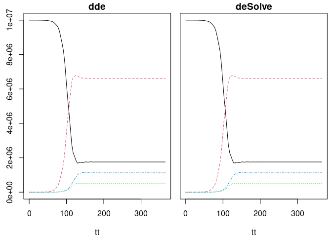

```r
yy_dde <- dde::dopri(y0, tt, seir, NULL, n_history = 1000L,
                     return_history = FALSE)
op <- par(mfrow=c(1, 2), mar=c(4, .5, 1.4, .5), oma=c(0, 2, 0, 0))
matplot(tt, yy_dde[, -1], type="l", main = "dde")
matplot(tt, yy_ds[, -1], type="l", main = "deSolve", yaxt="n")
```

```r
tR <- microbenchmark::microbenchmark(times = 30,
  deSolve = deSolve::dede(y0, tt, seir_deSolve, initial),
  dde = dde::dopri(y0, tt, seir, NULL, n_history = 1000L,
                   return_history = FALSE))
tR
```

```
## Unit: milliseconds
##     expr       min        lq      mean    median        uq       max neval
##  deSolve 12.290501 12.620859 13.322217 13.064936 13.736908 16.442861    30
##      dde  5.284014  5.357495  5.824103  5.517751  5.837586  7.358195    30
```

### Models implemented in C

The compiled code interface for `deSolve` has greatly influenced `dde` and models implemented in either framework will be similar. Eventually `dde` may support a fully `deSolve` compatible interface but for now there are a few differences.

```c
#include <R.h>
#include <R_ext/Rdynload.h>

void lagvalue(double tau, int *nr, int N, double *ytau);

// The parameters are going to be arranged:
//
//   t0
//   S0, I0
//   (b, N, beta, sigma, delta, t_latent)
//
// See below for why t0, S0 and I0 are stored
static double parms[3];

// The standard deSolve initialisation function
void seir_initmod(void (* odeparms)(int *, double *)) {
  int N = 3;
  odeparms(&N, parms);
}

// The RHS
void seir_deSolve(int *n, double *t, double *y, double *dydt,
                  double *yout, int *ip) {
  // again, hard-coded parameters for now; will change this shortly
  // once I get the same working with the dde impementation.
  double b = 0.1, N = 1e7, beta = 10.0, sigma = 1.0 / 3.0,
    delta = 1.0 / 21.0, t_latent = 14.0;
  double Births = N * b, surv = exp(-b * t_latent);

  // Because of the way that deSolve implements delays we need to
  // store the initial time and values in the parameters vector; if
  // the requested time is earlier than the time we started at then
  // the initial values need to be used, which we also store in the
  // parameters.
  double t0 = parms[0];
  const double tau = *t - t_latent;
  static int idx[2] = {0, 2};
  double S_lag, I_lag;
  if (tau <= t0) {
    S_lag = parms[1];
    I_lag = parms[2];
  } else {
    double ylag[2];
    lagvalue(tau, idx, 2, ylag);
    S_lag = ylag[0];
    I_lag = ylag[1];
  }

  const double S = y[0], E = y[1], I = y[2], R = y[3];
  const double new_inf = beta * S * I / N;
  const double lag_inf = beta * S_lag * I_lag * surv / N;

  dydt[0] = Births  - b * S - new_inf + delta * R;
  dydt[1] = new_inf - lag_inf - b * E;
  dydt[2] = lag_inf - (b + sigma) * I;
  dydt[3] = sigma * I - b * R - delta * R;
}

// This is the interface to deSolve's lag functions.  Note that unlike
// dde you are responsible for checking for underflows and providing
// values for underflowed times.
void lagvalue(double tau, int *nr, int N, double *ytau) {
  typedef void lagvalue_t(double, int *, int, double *);
  static lagvalue_t *fun = NULL;
  if (fun == NULL) {
    fun = (lagvalue_t*) R_GetCCallable("deSolve", "lagvalue");
  }
  fun(tau, nr, N, ytau);
}
```

- `parms` (or whatever parameters are called) are handled as a global variable that is updated via a model initialisation function, whereas in `dde` they’re passed in as a `void` pointer
- We need to keep track of the initial state of the system via passing in `t0` and initial conditions for `S` and `I` * There is an argument `double *yout` for additional output variables (of length `*ip`; in `dde` these are handled via a separate function.
- The lagvalue function must be explicitly defined (which requires loading some R-related headers (in `dde` this is achieved by including `<dde/dde.h>` and `<dde/dde.c>`.

Apart from these details, the model definition should appear very similar.

```r
initial <- c(0.0, y0[[1]], y0[[3]])

zz_ds <- deSolve::dede(y0, tt, "seir_deSolve", initial,
                       initfunc = "seir_initmod", dllname = "dde_seir_ds")
zz_dde <- dde::dopri(y0, tt, "seir", numeric(), dllname = "dde_seir",
                     n_history = 1000L, return_history = FALSE)
```

Check that outputs of these models are the same as the R version above:

```r
all.equal(zz_ds, yy_ds, check.attributes = FALSE)
```

```
## [1] TRUE
```

```r
all.equal(zz_dde, yy_dde, check.attributes = FALSE)
```

```
## [1] TRUE
```

```r
tC <- microbenchmark::microbenchmark(
  deSolve = deSolve::dede(y0, tt, "seir_deSolve", initial,
                          initfunc = "seir_initmod", dllname = "dde_seir_ds"),
  dde = dde::dopri(y0, tt, "seir", numeric(), dllname = "dde_seir",
                   n_history = 1000L, return_history = FALSE))
tC
```

```
## Unit: microseconds
##     expr     min      lq     mean  median       uq      max neval
##  deSolve 397.007 417.729 459.7357 432.315 458.3505 1892.766   100
##      dde 763.870 789.039 825.8974 812.150 846.1010 1180.685   100
```

The difference in speed will tend to increase as the models become larger (in terms of numbers of equations and parameters). On the other hand, constructing large models in C can be a hassle (but see [odin](https://mrc-ide.github.io/odin/) for a possible solution).

You can extract a little more performance by tweaking options to `dde::dopri`; in particular, adding `return_minimal = TRUE` will avoid transposing the output, binding the times on, and (if given) avoiding binding output variables. These costs may be nontrivial with bigger models, though the cost of running a larger model will likely be larger still. Previous version of R suffered from a large cost of looking up the address of the compiled function (Windows may still take longer to do this than macOS/Linux). In that case, use `getNativeSymbolInfo("seir")` and pass that through to `dopri` as the `func` argument.

```r
ptr <- getNativeSymbolInfo("seir")
tC2 <- microbenchmark::microbenchmark(
  deSolve = deSolve::dede(y0, tt, "seir_deSolve", initial,
                          initfunc = "seir_initmod", dllname = "dde_seir_ds"),
  dde = dde::dopri(y0, tt, "seir", numeric(), dllname = "dde_seir",
                   n_history = 1000L, return_history = FALSE),
  dde2 = dde::dopri(y0, tt, ptr, numeric(), n_history = 1000L,
                    return_history = FALSE, return_minimal = TRUE))
tC2
```

```
## Unit: microseconds
##     expr     min       lq     mean   median       uq      max neval
##  deSolve 387.409 403.9675 443.1914 415.8515 442.3460 1909.326   100
##      dde 753.237 772.9680 800.4689 780.9680 805.8260 1258.186   100
##     dde2 725.584 740.2925 761.3008 746.6520 755.3735 1038.110   100
```